# Varihedsanalyse_mini1

# Opgave 3

```r
Sur1 <- Surv(Cdata$Time, Cdata$Death_Censoring) # our survival
Cox.fit <- coxph(Sur1~ factor(Treatment)+ factor(Sex)+ factor(Ascites)+ Age+ Prothrombin, data = Cdata)
Cox.fit
```

```
## Call:
## coxph(formula = Sur1 ~ factor(Treatment) + factor(Sex) + factor(Ascites) +
##     Age + Prothrombin, data = Cdata)
##
##                         coef exp(coef)  se(coef)      z        p
## factor(Treatment)1  0.067070  1.069371  0.117868  0.569   0.5693
## factor(Sex)1        0.525289  1.690948  0.126974  4.137 3.52e-05
## factor(Ascites)1    0.441588  1.555174  0.179236  2.464   0.0138
## factor(Ascites)2    0.974063  2.648684  0.181719  5.360 8.31e-08
## Age                 0.049151  1.050378  0.006764  7.266 3.70e-13
## Prothrombin        -0.012923  0.987161  0.002917 -4.431 9.39e-06
##
## Likelihood ratio test=129.5  on 6 df, p=< 2.2e-16
## n= 488, number of events= 292
```

```r
summary(Cox.fit)
```

```
## Call:
## coxph(formula = Sur1 ~ factor(Treatment) + factor(Sex) + factor(Ascites) +
##     Age + Prothrombin, data = Cdata)
##
##   n= 488, number of events= 292
##
##                         coef exp(coef)  se(coef)      z Pr(>|z|)
## factor(Treatment)1  0.067070  1.069371  0.117868  0.569   0.5693
## factor(Sex)1        0.525289  1.690948  0.126974  4.137 3.52e-05 ***
## factor(Ascites)1    0.441588  1.555174  0.179236  2.464   0.0138 *
## factor(Ascites)2    0.974063  2.648684  0.181719  5.360 8.31e-08 ***
## Age                 0.049151  1.050378  0.006764  7.266 3.70e-13 ***
## Prothrombin        -0.012923  0.987161  0.002917 -4.431 9.39e-06 ***
## ---
## Signif. codes:  0 '***' 0.001 '**' 0.01 '*' 0.05 '.' 0.1 ' ' 1
##
##                    exp(coef) exp(-coef) lower .95 upper .95
## factor(Treatment)1    1.0694     0.9351    0.8488    1.3473
## factor(Sex)1          1.6909     0.5914    1.3184    2.1688
## factor(Ascites)1      1.5552     0.6430    1.0945    2.2098
## factor(Ascites)2      2.6487     0.3775    1.8550    3.7819
## Age                   1.0504     0.9520    1.0365    1.0644
## Prothrombin           0.9872     1.0130    0.9815    0.9928
##
## Concordance= 0.696  (se = 0.017 )
## Likelihood ratio test= 129.5  on 6 df,   p=<2e-16
## Wald test            = 132.3  on 6 df,   p=<2e-16
## Score (logrank) test = 142.4  on 6 df,   p=<2e-16
```

we look at the p-value of treatment and see that it is not significant, resulting in Treatment not affecting the result.

# Opgave 4

We pull out different variables to see the effect, leveled varables are not of intresed since all information have be extracted.

Looking at the model without Age

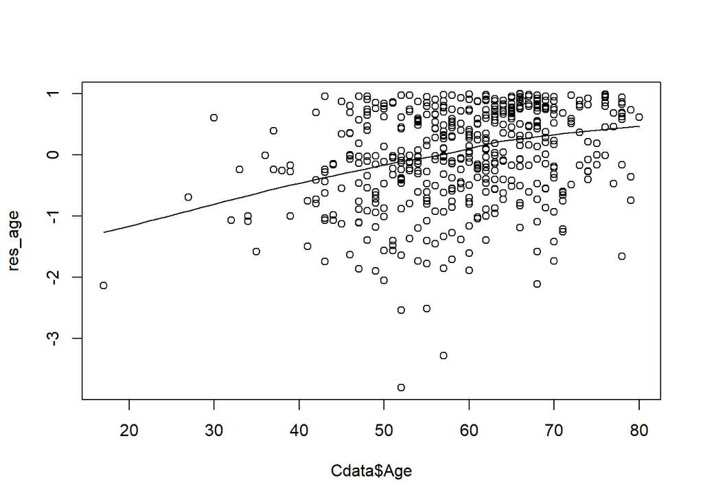

```r
Sur1 <- Surv(Cdata$Time, Cdata$Death_Censoring)
Cox.fit._age <- coxph(Sur1~ factor(Treatment)+ factor(Sex)+ factor(Ascites)+ Prothrombin, data = Cdata) # Fitting Cox model
res_age=residuals(Cox.fit._age) #residuals
scatter.smooth(Cdata$Age, res_age)
```

Using martingales residuals we see a linear behaviour for Age, indicating that using Age as a linear term is correct.

Looking at the model without Prothrombin

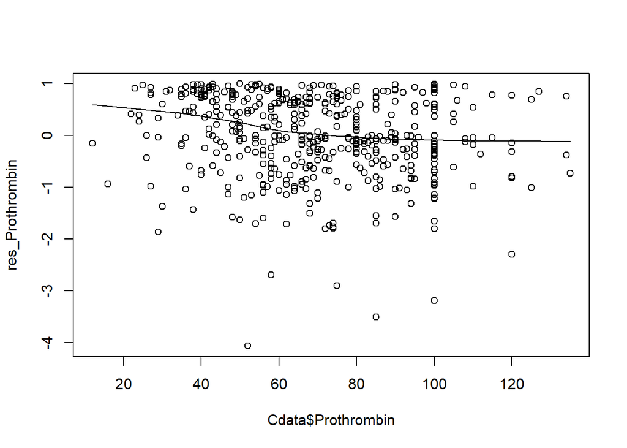

```r
Sur1 <- Surv(Cdata$Time, Cdata$Death_Censoring)
Cox.fit._Prothrombin <- coxph(Sur1~ factor(Treatment)+ factor(Sex)+ factor(Ascites)+ Age, data = Cdata) # Fitting Cox model
res_Prothrombin=residuals(Cox.fit._Prothrombin) #residuals
scatter.smooth(Cdata$Prothrombin, res_Prothrombin)
```